# Overview of behaviour

In this script, we want to get a general overview of participants’ behaviour. For this, we create various plots. Lisa Spiering, 2025

# Task

## Fig 1D: task schedule

plot an example task block

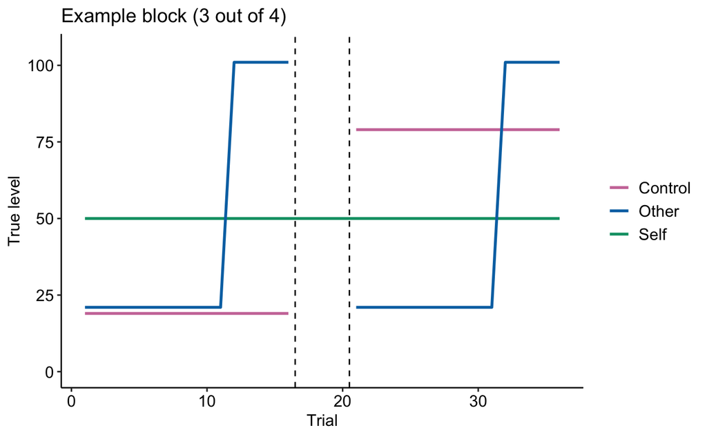

```r
game2plot = 3
dataB.mri %>% filter(game_number==game2plot) %>% mutate(player_mu=ifelse(phase!=2,player_mu,NA), control_level=ifelse(phase!=2,100*control_level,NA)) %>%
  select(game_trial,control_level,player_mu,self_mu,game_number) %>% unique() %>%
  ggplot(., aes(x=game_trial)) + geom_vline(xintercept = 16.5,lty='dashed') + geom_vline(xintercept = 20.5,lty='dashed') +
  geom_line(aes(y=control_level-1,color='Control',size='Truth'), size=1) + geom_line(aes(y=self_mu,color='Self',size='Truth'),size=1) +
  geom_line(aes(y=player_mu+1,color='Other',size='Truth'),size=1) +
  scale_color_manual(values=c(cols$Control,cols$Other,cols$Self)) +
  ylim(0,105) + ylab("True level") + xlab("Trial") + ggtitle(paste0('Example block (',game2plot,' out of 4)')) +
  theme_pubr() + theme(legend.position = 'right',legend.title = element_blank(),legend.text=element_text(size=12))
```

```r
#ggsave(file.path(path$figs,'Fig01','Fig01d_phases.png'),width=5,height=2.5)
#ggsave(file.path(path$figs,'Fig01','Fig01d_phases.svg'),width=5,height=2.5) # vector graphic
```

## Supplementary figure 2: Feedback function

illustrate the feedback function

[figure not shown]

```r
# PANEL A: self feedback function
# get some example values from first participant
nsamples=500
# log((1/(1- settings.perfToFeedbackSlopeValue )) - 1) / (trialResps.performanceMean - trialResps.performanceMin))
slope = log((1/(1-0.55)) - 1) / (dataB.mri$performanceMean[1] - dataB.mri$performanceMin[1])

# simulate data points
dat2plotA = data.frame(perferror = c(1:nsamples,1:nsamples,1:nsamples),
                       self_mu = c(rep(20,nsamples),rep(50,nsamples),rep(80,nsamples))) %>%
  mutate(shift = dataB.mri$performanceMean[1] + (log(1/(1- self_mu/100) - 1) /   slope),
         self_fb = (1-1/(1+exp(slope*(shift-perferror))))*100,
         self_mu2 = as.factor(self_mu))

# plot
panelA = dat2plotA %>% ggline('perferror','self_fb',color='self_mu2',plot_type = 'l',size=1) +
  geom_point(aes(x=dataB.mri$performanceMean[1],y=20),size=2)+
  geom_point(aes(x=dataB.mri$performanceMean[1],y=50),size=2)+
  geom_point(aes(x=dataB.mri$performanceMean[1],y=80),size=2)+
  scale_color_manual(values=c('#00FF00','#00CC00','#009900'),name = 'Mapping',labels=c('hard','medium','easy')) +
  ylim(0,100) + ylab('Mapped self performance [points]') + xlab('Objective performance error [pixels]') + ggtitle('Mapping of self performance',subtitle = '(data from example participant)') +
  theme_pubr(base_size = 14) + theme(legend.position = 'bottom',legend.direction = 'vertical',legend.text=element_text(size=14))

# Panel B: illustrate staircasing for performance drifts
dat2plotB = dataB.mri.w0AD %>% filter(game_number==1,ID==2,active_trial==0) %>% mutate(trialcounter = 1:n(),self_fb = self_feedback+60)
panelB = dat2plotB %>% ggplot(aes(x=trialcounter)) + geom_point(aes(y=perferror_abs,color='Objective performance error [pixels]'),size=2) +
  geom_point(aes(y=self_fb,color='Mapped self performance [points]'),size=2) +
  ylab('Performance') + xlab('Trial') + theme(legend.position = 'right') + ylim(50,200)+
  scale_color_manual(values=c('black','red'),name=element_blank()) + ggtitle('Staircasing of self performance',subtitle = '(data from example participant)') +
  theme_pubr(base_size = 14) + theme(legend.position='bottom',legend.direction = 'vertical',legend.text=element_text(size=14))

# plot both together
ggarrange(panelA,panelB,ncol=2,align='h')
```

```r
#ggsave(file.path(path$figs,'Supplementals','FigX_task_selffeedback_raw.jpg'),width=10,height=6)
```

# Demographics

```r
# included MRI subjects
dataQ.mri %>% nrow() %>% paste0('Number of included subjects in MRI sample: ', .) %>% print()
```

```
[1] "Number of included subjects in MRI sample: 31"
```

```r
dataQ.mri %>% select(gender) %>% table()
```

```
gender
 F  M
22  9
```

```r
dataQ.mri %>% select(age) %>% range() %>% paste0(.,' years',collapse=' - ') %>% print()
```

```
[1] "18 years - 33 years"
```

```r
# included online - those we use for active disambiguation analyses
dataQ.online %>% nrow() %>% paste0('Number of included subjects in Online sample - with ADs: ', .) %>% print()
```

```
[1] "Number of included subjects in Online sample - with ADs: 36"
```

```r
dataQ.online %>% select(Gender) %>% table()
```

```
Gender
Diverse  Female    Male
      1      21      14
```

```r
dataQ.online %>% select(Age) %>% range() %>% paste0(.,' years',collapse=' - ') %>% print()
```

```
[1] "18 years - 40 years"
```

[1] “Number of included subjects in MRI sample: 31” gender F M 22 9 [1] “18 years - 33 years” [1] “Number of included subjects in Online sample - with ADs: 36” Gender Diverse Female Male 1 21 14 [1] “18 years - 40 years”

# Overall ratings

## Fig 2B: average ratings

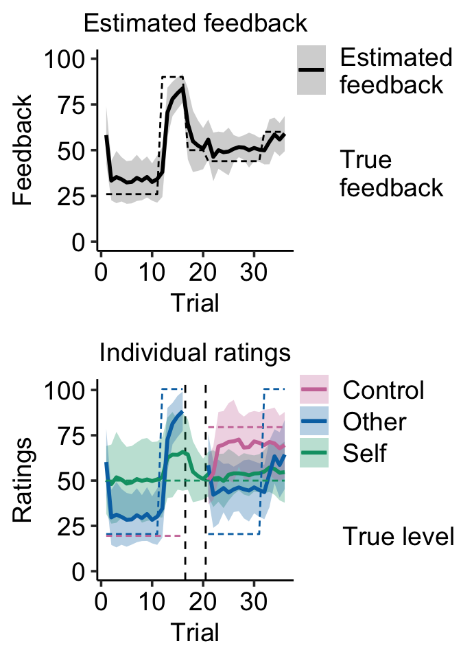

```r
game2plot = 3

p1 = dataB.mri %>% filter(game_number==game2plot) %>%
  group_by(game_number,game_trial) %>% dplyr::summarize(rate_total_mu = mean(rate_total), rate_total_sd = sd(rate_total), feedback_mu = unique(feedback_mu) ) %>%
  ggplot(., aes(x=game_trial)) +
  geom_line(aes(y=feedback_mu,color='Estimated\nfeedback',lty='Feedback')) +
  geom_line(aes(y=rate_total_mu,color='Estimated\nfeedback',lty='Estimated\nfeedback'),size=1) +
  geom_ribbon(aes(ymin=rate_total_mu-rate_total_sd,ymax=rate_total_mu+rate_total_sd,fill='Estimated\nfeedback'),alpha=0.2) +
  xlab("Trial") + ylab('Feedback') + ylim(0,100) + ggtitle('Estimated feedback') +
  scale_color_manual(NULL,values=c('black','black')) + scale_fill_manual(NULL,values=c('black','black')) +
  scale_linetype_manual(NULL,values=c(32,'solid'),breaks=c('Feedback','Estimated\nfeedback'),labels=c('True\nfeedback',element_blank())) +
  guides(color = guide_legend(order=1), fill=guide_legend(order=1),lty = guide_legend(order=2,override.aes = list(lty = NA))) +
  theme(legend.position = 'right', legend.box = "vertical",plot.title = element_text(hjust = 0.5,size=14),legend.justification = 'top',legend.box.margin=margin(-10,-10,-10,-20),legend.background=element_rect(fill='transparent'),legend.text=element_text(size=14))
p2 = dataB.mri %>% filter(game_number==game2plot) %>% group_by(game_number,game_trial) %>%
  dplyr::summarize(self_mu=unique(self_mu),player_mu=ifelse(phase!=2,unique(player_mu),NA), control=ifelse(phase!=2,100*unique(control_level),NA),
                   rate_selfsd = sd(rate_self),rate_othersd = sd(rate_other),rate_ctrlsd=100*sd(rate_ctrl ), # needs to come first as otherwise next line overwrites original data points
                   rate_self = mean(rate_self),rate_other = mean(rate_other),rate_ctrl=100*mean(rate_ctrl )) %>% distinct() %>% mutate(game4plot = paste('Block',game_number)) %>%
  ggplot(., aes(x=game_trial)) +     geom_vline(xintercept = 16.5,lty='dashed') + geom_vline(xintercept = 20.5,lty='dashed') +
  geom_ribbon(aes(ymin=rate_self-rate_selfsd,ymax=rate_self+rate_selfsd, fill='Self'),alpha=0.3) +
  geom_ribbon(aes(ymin=rate_other-rate_othersd,ymax=rate_other+rate_othersd, fill='Other'),alpha=0.3) +
  geom_ribbon(aes(ymin=rate_ctrl-rate_ctrlsd,ymax=rate_ctrl+rate_ctrlsd, fill='Control'),alpha=0.3) +
  geom_line(aes(y=rate_self,color='Self',lty='Rating'),size=1) + geom_line(aes(y=rate_other,color='Other',lty='Rating'),size=1) + geom_line(aes(y=rate_ctrl,color='Control',lty='Rating'),size=1) +
  geom_line(aes(y=self_mu,color='Self',lty='Truth')) + geom_line(aes(y=player_mu+0.5,color='Other',lty='Truth')) + geom_line(aes(y=control-0.5,color='Control',lty='Truth')) +
  ylab("Ratings") + xlab("Trial") + ggtitle('Individual ratings') + ylim(0,101) + # 101 bc otherwise player_mu=100 is cut off
  scale_linetype_manual(NULL,values=c(32,'solid'),breaks=c('Truth','Rating'),labels=c('True level',element_blank())) + scale_color_manual(NULL,values=c(cols$Control,cols$Other,cols$Self)) + scale_fill_manual(NULL,values=c(cols$Control,cols$Other,cols$Self)) +
  guides(color = guide_legend(order=1), fill=guide_legend(order=1),lty = guide_legend(order=2,override.aes=list(lty=NA)))+
  theme(legend.position = 'right', legend.box = "vertical",plot.title = element_text(hjust = 0.5,size=14),legend.justification = 'top',legend.box.margin=margin(-10,-10,-10,-20),legend.background=element_rect(fill='transparent'),legend.text=element_text(size=14))
# plot both together
ggarrange(p1,p2,nrow=2,align='v')
```

```r
#ggsave(file.path(path$figs,'Fig02','Fig02BC.jpg'),width = 8.5,height=12,units = 'cm')
#ggsave(file.path(path$figs,'Fig02','Fig02BC.svg'),width = 8.5,height=12,units = 'cm')
```

rate_total_err is relevant here - is predicted feedback substracted by true feedback I take the first and last trial predrift

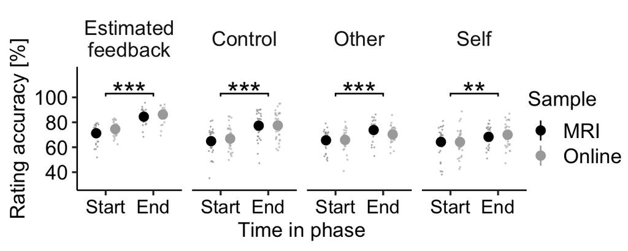

```r
data2analyse = lapply(list(mri = dataB.mri,online = dataB.online),
                      function(.x) {
                        .x %>% filter(phase%in%c(1,3),phase_trial%in%c(1,11)) %>%
                          mutate(phase_section      = ifelse(phase_trial<4,1,2),
                                 rate_total_err_max = ifelse(feedback_mu<50,100 - feedback_mu, feedback_mu),
                                 rate_total_acc     = 100 * (1 - rate_total_err / rate_total_err_max),
                                 rate_self_err_max  = ifelse(self_mu<50,100 - self_mu, self_mu),
                                 rate_self_acc      = ifelse(phase==1,100 * (1 - rate_self_err / rate_self_err_max),NA),
                                 rate_other_err_max = ifelse(player_mu<50,100 - player_mu, player_mu),
                                 rate_other_acc     = 100 * (1 - rate_other_err / rate_other_err_max),
                                 rate_ctrl_err_max  = ifelse(control_level<0.5,1 - control_level, control_level),
                                 rate_ctrl_acc      = 100 * (1 - rate_ctrl_err / rate_ctrl_err_max)) %>% group_by(ID,phase_section) %>%
                          dplyr::summarise(rate_total_acc = mean(rate_total_acc),
                                           rate_self_acc  = mean(rate_self_acc,na.rm=T),
                                           rate_other_acc = mean(rate_other_acc),
                                           rate_ctrl_acc  = mean(rate_ctrl_acc,na.rm=T))
                      }
)
data2plot = rbind(data2analyse$mri %>% mutate(Sample='MRI'), data2analyse$online %>% mutate(Sample='Online')) %>% mutate(ID=as.factor(ID),Sample=factor(Sample,levels=c('MRI','Online')))
data2plot2 = data2plot %>% pivot_longer(.,cols=c('rate_total_acc','rate_self_acc','rate_other_acc','rate_ctrl_acc'),names_to='acc',values_to = 'value') %>%
  mutate(acc_titles = ifelse(acc=='rate_ctrl_acc','Control',ifelse(acc=='rate_self_acc','Self',ifelse(acc=='rate_other_acc','Other',ifelse(acc=='rate_total_acc',' Estimated \nfeedback',NA))))) # space in ' Estimated\noutcome' is so that this panel comes first

p = data2plot2 %>% ggerrorplot(.,'phase_section','value',desc_stat = 'mean_se',color='Sample',
                               ylab='Rating accuracy [%]', xlab='Time in phase',ylim=c(30,120),size=0.5,
                               add='jitter',add.params = list(alpha=0.5,size=0.1,shape=21,color='grey',fill='Sample')) +
  scale_x_discrete(labels=c("1" = "Start", "2" = "End"))+ scale_y_continuous(breaks=seq(40,100,20)) + scale_color_manual(values=c('black','darkgrey')) + scale_fill_manual(values=c('black','darkgrey')) +
  # for adding stars for significance, we actually need an anova - but this function can't do it so I modify the significance levels of the used ttest to reflect the correct stars that I manually computed in the following chunk
  geom_signif(comparisons = list(c("1", "2")), test.args = list(paired=T), map_signif_level=c("***"=0.001, "**"=0.01,"*"=0.05),y_position = 100,textsize = 7,vjust=0.5) +
  theme_pubr(base_size=14) +theme(legend.position = 'right',legend.text=element_text(size=14),legend.box.margin=margin(0,-10,0,-20),axis.text.x = element_text(size=13))
facet(p,facet.by = 'acc_titles',nrow=1,ncol=4,panel.labs.background = list(fill='white',color='white'),panel.labs.font=list(size=14))
```

```r
#ggsave(file.path(path$figs,'Fig02','Fig02D.jpg'),width = 14,height=6.5,units = 'cm')
#ggsave(file.path(path$figs,'Fig02','Fig02D.svg'),width = 14,height=6.5,units = 'cm')
```

do ratings improve over time?

```r
# A) TOTAL RATING ACCURACY
# anova across samples: between = sample; within: time in block
data4anova = data2plot %>% pivot_longer(cols = c('rate_total_acc','rate_self_acc','rate_other_acc','rate_ctrl_acc'),values_to = 'accuracy',names_to='ratingtype') %>% as.data.frame() %>% mutate(ID = ifelse(Sample=='Online',as.numeric(ID)+100,ID)) # make ID a unique number across samples
rstatix::anova_test(data = data4anova%>%filter(ratingtype=='rate_total_acc'), dv = accuracy, wid = ID, within = phase_section, between = c(Sample))
```

```
ANOVA Table (type III tests)

                Effect DFn DFd       F        p p<.05   ges
1               Sample   1  65   6.255 1.50e-02     * 0.046
2        phase_section   1  65 150.668 1.38e-18     * 0.535
3 Sample:phase_section   1  65   0.634 4.29e-01       0.005
```

```r
# B) CONTROL RATING
# anova across samples: between = sample; within: time in block -> post-hoc ttests within sample not done bc no sign main effect or interaction with sample
rstatix::anova_test(data = data4anova%>%filter(ratingtype=='rate_ctrl_acc'), dv = accuracy, wid = ID, within = phase_section, between = c(Sample))
```

```
ANOVA Table (type III tests)

                Effect DFn DFd      F        p p<.05   ges
1               Sample   1  65  0.432 5.13e-01       0.003
2        phase_section   1  65 38.374 4.47e-08     * 0.246
3 Sample:phase_section   1  65  0.248 6.21e-01       0.002
```

```r
# C) OTHER RATING
# anova across samples: between = sample; within: time in block
rstatix::anova_test(data = data4anova%>%filter(ratingtype=='rate_other_acc'), dv = accuracy, wid = ID, within = phase_section, between = c(Sample))
```

```
ANOVA Table (type III tests)

                Effect DFn DFd      F        p p<.05   ges
1               Sample   1  65  2.328 1.32e-01       0.012
2        phase_section   1  65 18.546 5.72e-05     * 0.159
3 Sample:phase_section   1  65  1.639 2.05e-01       0.016
```

```r
# D) SELF RATING
# anova across samples: between = sample; within: time in block
rstatix::anova_test(data = data4anova%>%filter(ratingtype=='rate_self_acc'), dv = accuracy, wid = ID, within = phase_section, between = c(Sample))
```

```
ANOVA Table (type III tests)

                Effect DFn DFd      F     p p<.05   ges
1               Sample   1  65  0.205 0.652       0.002
2        phase_section   1  65 11.038 0.001     * 0.063
3 Sample:phase_section   1  65  0.372 0.544       0.002
```

ANOVA Table (type III tests)

Effect DFn DFd F p p<.05 ges 1 Sample 1 65 6.255 1.50e-02 * 0.046 2 phase_section 1 65 150.668 1.38e-18 * 0.535 3 Sample:phase_section 1 65 0.634 4.29e-01 0.005 ANOVA Table (type III tests)

Effect DFn DFd F p p<.05 ges 1 Sample 1 65 0.432 5.13e-01 0.003 2 phase_section 1 65 38.374 4.47e-08 * 0.246 3 Sample:phase_section 1 65 0.248 6.21e-01 0.002 ANOVA Table (type III tests)

Effect DFn DFd F p p<.05 ges 1 Sample 1 65 2.328 1.32e-01 0.012 2 phase_section 1 65 18.546 5.72e-05 * 0.159 3 Sample:phase_section 1 65 1.639 2.05e-01 0.016 ANOVA Table (type III tests)

Effect DFn DFd F p p<.05 ges 1 Sample 1 65 0.205 0.652 0.002 2 phase_section 1 65 11.038 0.001 * 0.063 3 Sample:phase_section 1 65 0.372 0.544 0.002

test that accuracy of individual ratings don’t increase as much as for the combined feedback

```r
# across samples
data4anova2 = data2plot %>% mutate(ID = ifelse(Sample=='Online',as.numeric(ID)+100,ID))

data4anova2.2 = data4anova2 %>% group_by(ID,phase_section) %>%
  pivot_wider(id_cols=c('ID','Sample'),names_from = 'phase_section',values_from = c(rate_total_acc,rate_self_acc, rate_other_acc, rate_ctrl_acc)) %>%
  mutate(rate_total_diff = rate_total_acc_2 - rate_total_acc_1,
         rate_self_diff  = rate_self_acc_2 - rate_self_acc_1,    rate_other_diff = rate_other_acc_2 - rate_other_acc_1,   rate_ctrl_diff = rate_ctrl_acc_2 - rate_ctrl_acc_1,
         rate_indiv_diff = mean(c(rate_self_diff,rate_other_diff,rate_ctrl_diff))) %>%
  pivot_longer(cols=c('rate_total_diff','rate_indiv_diff'),values_to='acc_diff',names_to='ratingtype') %>% as.data.frame()
rstatix::anova_test(data4anova2.2, dv = 'acc_diff', wid="ID",within = 'ratingtype', between = c('Sample'))
```

```
ANOVA Table (type III tests)

             Effect DFn DFd      F        p p<.05      ges
1            Sample   1  65  0.553 4.60e-01       0.007000
2        ratingtype   1  65 32.393 3.26e-07     * 0.075000
3 Sample:ratingtype   1  65  0.043 8.37e-01       0.000107
```

```r
data4anova2.2 %>% group_by(ratingtype) %>% dplyr::summarise(mu = mean(acc_diff))# mean total vs individual rating accuracies
```

| ratingtype | mu |
| --- | --- |
| rate_indiv_diff | 7.548344 |
| rate_total_diff | 12.403816 |

ANOVA Table (type III tests)

Effect DFn DFd F p p<.05 ges 1 Sample 1 65 0.553 4.60e-01 0.007000 2 ratingtype 1 65 32.393 3.26e-07 * 0.075000 3 Sample:ratingtype 1 65 0.043 8.37e-01 0.000107

ratingtype mu rate_indiv_diff 7.548344  
rate_total_diff 12.403816

## Supplementary figure 3: average ratings in all blocks, both samples

[figure not shown]

```r
plot_ratings = function(data) {
  data %>% group_by(game_number,game_trial) %>%
    dplyr::summarize(self_mu=unique(self_mu),player_mu=ifelse(phase!=2,unique(player_mu),NA), control=ifelse(phase!=2,100*unique(control_level),NA),
                     rate_selfsd = sd(rate_self),rate_othersd = sd(rate_other),rate_ctrlsd=100*sd(rate_ctrl ), # needs to come first as otherwise next line overwrites original data points
                     rate_self = mean(rate_self),rate_other = mean(rate_other),rate_ctrl=100*mean(rate_ctrl )) %>% distinct() %>% mutate(game4plot = paste('Block',game_number)) %>%
    ggplot(., aes(x=game_trial)) + facet_wrap(~game_number,ncol = 4) +
    geom_ribbon(aes(ymin=rate_self-rate_selfsd,ymax=rate_self+rate_selfsd, fill='Self'),alpha=0.3) +
    geom_ribbon(aes(ymin=rate_other-rate_othersd,ymax=rate_other+rate_othersd, fill='Other'),alpha=0.3) +
    geom_ribbon(aes(ymin=rate_ctrl-rate_ctrlsd,ymax=rate_ctrl+rate_ctrlsd, fill='Control'),alpha=0.3) +
    geom_line(aes(y=rate_self,color='Self'),size=1) + geom_line(aes(y=rate_other,color='Other'),size=1) + geom_line(aes(y=rate_ctrl,color='Control'),size=1) +
    geom_line(aes(y=self_mu,color='Self'),lty=32) + geom_line(aes(y=player_mu+0.5,color='Other'),lty=32) + geom_line(aes(y=control-0.5,color='Control'),lty=32) +
    ylab("Ratings") + xlab("Trial") + ggtitle('Individual ratings') + ylim(0,100) +
    scale_color_manual(NULL,values=c(cols$Control,cols$Other,cols$Self)) + scale_fill_manual(NULL,values=c(cols$Control,cols$Other,cols$Self)) +
    guides(color = guide_legend(order=1), fill=guide_legend(order=1))+
    theme(plot.title = element_text(size=16),legend.text=element_text(size=14))
}
plot_estfb = function(data) {
  data %>% group_by(game_number,game_trial) %>%
    dplyr::summarize(rate_total_mu = mean(rate_total), rate_total_sd = sd(rate_total), feedback_mu = unique(feedback_mu) ) %>%
    ggplot(., aes(x=game_trial)) + facet_wrap(~game_number,ncol = 4) +
    geom_line(aes(y=feedback_mu,color='Estimated\nfeedback'),lty=32) +
    geom_line(aes(y=rate_total_mu,color='Estimated\nfeedback'),size=1) +
    geom_ribbon(aes(ymin=rate_total_mu-rate_total_sd,ymax=rate_total_mu+rate_total_sd,fill='Estimated\nfeedback'),alpha=0.2) +
    xlab("Trial") + ylab('Estimated feedback') + ylim(0,100) + ggtitle('Estimated feedback') +
    scale_color_manual(NULL,values=c('black','black')) + scale_fill_manual(NULL,values=c('black','black')) +
    guides(color = guide_legend(order=1), fill=guide_legend(order=1)) +
    theme(plot.title = element_text(size=16),legend.text=element_text(size=14))
}
# plot both together
ggarrange(ggarrange(dataB.mri%>%plot_ratings(.)+ggtitle('MRI: Individual ratings'),
                    dataB.online%>%plot_ratings(.)+ggtitle('Online: Individual ratings'),common.legend=T,legend='right'),
          ggarrange(dataB.mri%>%plot_estfb(.)+ggtitle('MRI: Estimated feedback') ,
                    dataB.online%>%plot_estfb(.)+ggtitle('Online: Estimated feedback'),common.legend = T,legend='right'),nrow=2)
```

```r
# save
#ggsave(file.path(path$figs,'Supplementals','FigX_beh_avgratings_raw.jpg'),width = 34,height=15,units = 'cm')
```

# Active disambiguation

## Fig 3C-D: AD in behaviour and debrief

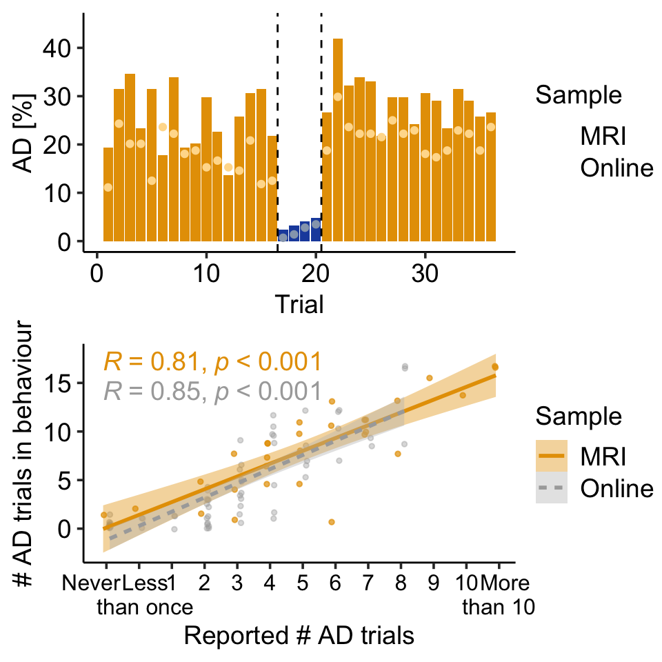

```r
# 3Bi: Detected ADs across trials per phase
data2plot = list(
  mri = dataB.mri %>% group_by(ID,game_trial,phase) %>% dplyr::summarise(mu_ATs = mean(as.numeric(active_trial)-1)) %>% ungroup() %>%
    group_by(game_trial,phase) %>% dplyr::summarise(prop_ATsubs = 100 * sum(mu_ATs)/length(unique(dataB.mri$ID)), isuncphase=ifelse(phase==2,0,1)) %>% distinct(),
  online = dataB.online %>% group_by(ID,game_trial,phase) %>% dplyr::summarise(mu_ATs = mean(as.numeric(active_trial)-1)) %>% ungroup() %>%
    group_by(game_trial,phase) %>% dplyr::summarise(prop_ATsubs = 100 * sum(mu_ATs)/length(unique(dataB.online$ID)), isuncphase=ifelse(phase==2,0,1)) %>% distinct())
# plot mri participants in bars, online participants as dots
p1 = data2plot$mri %>% ggplot(aes(x=game_trial,y=prop_ATsubs)) + geom_histogram(aes(fill=as.factor(isuncphase)),stat = 'identity') +
  geom_point(data = data2plot$online,aes(x=game_trial,y=prop_ATsubs,color=as.factor(isuncphase)),size=1.5,show.legend = F) +
  geom_vline(xintercept=c(16.5,20.5), linetype='dashed') +
  scale_fill_manual('Sample',values=c("#1F4EAB",cols$AD),labels=c('MRI','Online'))+ scale_color_manual(values=c("#96A5BA",cols$ADL)) +
  xlab("Trial") + ylab('AD [%]') + ylim(0,45) +
  guides(fill=guide_legend(override.aes=list(fill=NA))) + theme(legend.position='right',legend.text = element_text(size=14),legend.box.margin=margin(-10,-10,-10,-10));
# plot with correlation between total number and reported number

# MRI participants - include 3 subs again that we excluded bc no switch trials
tmp1 = dataB.mri.w0AD %>% group_by(ID) %>% dplyr::summarise(Behaviour_number = length(which(active_trial==1)) / 4)
tmp2 = dataQ.mri.w0AD %>% select(ID,DQ.Q5) %>% mutate(Reported_number = as.numeric(DQ.Q5))
dat2plot.mri = left_join(tmp1,tmp2,by='ID') %>% na.omit() %>% mutate(Sample='MRI')# 5 subs didn't have debrief so we removed them here -> from n=34 to n=29
# for online plot, we don't want to exclude anyone who didn't do/report ADs - i.e. we include full sample of n=66 without exclusion
tmp3 = dataB.online.w0AD %>% group_by(ID) %>% dplyr::summarise(Behaviour_number = length(which(active_trial==1)) / 4)
tmp4 = dataQ.online.w0AD %>% select(ID,DQ.ATFrq) %>% mutate(Reported_number = recode(DQ.ATFrq, 'Never' = -1, 'Less than once' = 0,'1'=1,'2'=2,'3'=3,'4'=4,'5'=5,'6'=6,'7'=7,'8'=8,'9'=9,'10'=10))
dat2plot.online = left_join(tmp3,tmp4,by='ID')%>% na.omit() %>% mutate(Sample='Online')# 2 subjects didn't answer question, so we have n=64
# put together
dat2plot = rbind(dat2plot.mri%>%select(-DQ.Q5), dat2plot.online%>%select(-DQ.ATFrq)) %>% mutate(Reported_number = ifelse(Sample=='MRI',Reported_number-0.1,Reported_number+0.1))
# plot
p2 = ggscatter(dat2plot,'Reported_number','Behaviour_number', fill='Sample', color='Sample',alpha='Sample',size=1, #add = 'reg.line',conf.int = T, #shape='Sample',
               xlab='Reported # AD trials',ylab='# AD trials in behaviour',position = position_jitter(width=0.03)) +
  stat_smooth(method=lm, aes(fill=Sample,color=Sample,linetype=Sample),fullrange = F) +
  stat_cor(aes(color = Sample),method='spearman',show.legend = F,label.y=c(17,14),size=5,p.accuracy=0.001) +
  scale_x_continuous(breaks=c(-1:11),label=c("Never     ","  Less\n  than once",1:10,"  More\nthan 10")) +
  scale_color_manual(values=c(cols$AD,'darkgrey')) + scale_fill_manual(values=c(cols$AD,'grey')) + scale_alpha_manual(values=c(0.7,0.4)) +
  guides(colour = guide_legend(override.aes = list(shape = NA))) + # remove dot from legend
  theme_pubr(base_size=14) + theme(legend.position = 'right',legend.text = element_text(size=14),legend.box.margin=margin(-10,-10,-10,-10),axis.text.x=element_text(size=12)) #,

# plot both together
ggarrange(p1,p2,nrow=2,align='v')
```

```r
#ggsave(file.path(path$figs,'Fig03','Fig03B.jpg'),width = 14,height=12.6,units = 'cm')
#ggsave(file.path(path$figs,'Fig03','Fig03B.svg'),width = 14,height=12.6,units = 'cm')

# included subjects just for this plot
dat2plot.mri$ID %>% unique() %>% length()
```

```
[1] 29
```

```r
dat2plot.online$ID %>% unique() %>% length()
```

```
[1] 64
```

```r
# get 95% CI for correlation reporting in text
print('MRI sample')
```

```
[1] "MRI sample"
```

```r
dat4cor = dat2plot %>% filter(Sample=='MRI')
DescTools::SpearmanRho(dat4cor$Reported_number,dat4cor$Behaviour_number,conf.level = 0.95)
```

```
      rho    lwr.ci    upr.ci
0.8085206 0.6281542 0.9064271
```

```r
print('ONLINE sample')
```

```
[1] "ONLINE sample"
```

```r
dat4cor = dat2plot %>% filter(Sample=='Online')
DescTools::SpearmanRho(dat4cor$Reported_number,dat4cor$Behaviour_number,conf.level = 0.95)
```

```
      rho    lwr.ci    upr.ci
0.8468978 0.7591182 0.9044276
```

```r
# for supplementals: # mean proportion of AD
data2plot$online %>% filter(phase!=2) %>% ungroup() %>% summarise(mean_prop = mean(prop_ATsubs)) # 19.62%
```

| mean_prop |
| --- |
| 19.61806 |

```r
data2plot$mri %>% filter(phase!=2) %>% ungroup() %>% summarise(mean_prop = mean(prop_ATsubs)) # 27.39%
```

| mean_prop |
| --- |
| 27.39415 |

for bottom sample: MRI has n=29, online has n=64

*95% CIs* [1] “MRI sample” rho lwr.ci upr.ci 0.8085206 0.6281542 0.9064271 [1] “ONLINE sample” rho lwr.ci upr.ci 0.8468978 0.7591182 0.9044276

For reporting in text: get mean proportion of participants exploring in each phase (across trials)

```r
dataB.mri %>% group_by(ID,game_trial,phase) %>% dplyr::summarise(mu_ATs = mean(as.numeric(active_trial)-1)) %>% group_by(game_trial,phase) %>% dplyr::summarise(prop_ATsubs = 100 * sum(mu_ATs)/length(unique(dataB.mri$ID))) %>%
  group_by(phase) %>% summarise(mri_mu_prop = mean(prop_ATsubs))
```

| phase | mri_mu_prop |
| --- | --- |
| 1 | 25.453629 |
| 2 | 3.629032 |
| 3 | 29.334677 |

```r
dataB.online %>% group_by(ID,game_trial,phase) %>% dplyr::summarise(mu_ATs = mean(as.numeric(active_trial)-1)) %>% group_by(game_trial,phase) %>% dplyr::summarise(prop_ATsubs = 100 * sum(mu_ATs)/length(unique(dataB.mri$ID))) %>%
  group_by(phase) %>% summarise(online_mu_prop = mean(prop_ATsubs))
```

| phase | online_mu_prop |
| --- | --- |
| 1 | 20.161290 |
| 2 | 2.419355 |
| 3 | 25.403226 |

MEan proportion of participants who explore in each phase: MRI: phase mu_prop 1 25.453629  
2 3.629032  
3 29.334677

Online: phase mu_prop 1 20.161290  
2 2.419355  
3 25.403226

## Supplementary Fig 9F: Debrief: Helpfulness of AD for ratings (online only)

Overview which rating was rated as most helpful in debrief

figure

```r
dat2plot = dataQ.online %>% select(ID,DQ.ATSelf.num, DQ.ATOther.num, DQ.ATCtrl.num) %>% pivot_longer(cols=c('DQ.ATSelf.num', 'DQ.ATOther.num', 'DQ.ATCtrl.num')) %>% mutate(ID=as.factor(ID),rating_type = as.factor(ifelse(name=='DQ.ATSelf.num',1,ifelse(name=='DQ.ATOther.num',2,3))),name2 = as.factor(ifelse(name=='DQ.ATSelf.num','Self',ifelse(name=='DQ.ATOther.num','Other','Control'))))
# participant numbers included
dat2plot %>% pull(ID) %>% unique() %>% length() # n=36
```

```
[1] 36
```

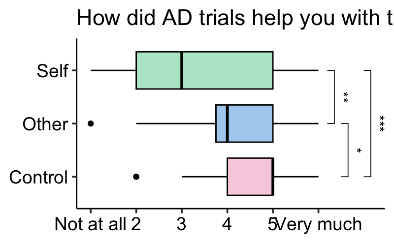

```r
# plot rating in a pretty way
dat2plot %>% ggboxplot(.,x='name2',y='value',xlab='',ylab='Rating',fill='name2', title='How did AD trials help you with the ratings?',orientation='horizontal') +
  stat_compare_means(comparisons=list(c('Self','Other'),c('Self','Control'),c('Other','Control')),method='t.test',paired=T,label.y = c(6.1,6.9,6.4),label='p.signif',symnum.args=list(cutpoints = c(0, 0.001, 0.01, 0.05, 1), symbols = c("***", "**", "*", "ns"))) +
  scale_fill_manual(values = c('Self'=cols$SelfL, 'Other' = cols$OtherL, 'Control'=cols$ControlL)) +
  scale_y_continuous(breaks=c(1:6),label=c("Not at all",'2','3','4','5',"Very much")) + theme_pubr(base_size=14) + theme(axis.title = element_blank(),legend.position = 'none')
```

```r
#ggsave(file.path(path$figs,'Fig04','Fig04C.jpg'),width = 14,height=5.6,units = 'cm') # conversion: do twice the image size you want to have for better resolution
```

stats

```r
# If you did badly on purpose, how did it help you with the ratings?
dataQ.online %>% select(DQ.ATSelf.num, DQ.ATOther.num, DQ.ATCtrl.num) %>% psych::describe()
```

|  | vars | n | mean | sd | median | trimmed | mad | min | max | range | skew | kurtosis | se |
| --- | --- | --- | --- | --- | --- | --- | --- | --- | --- | --- | --- | --- | --- |
| DQ.ATSelf.num | 1 | 36 | 3.25 | 1.68 | 3 | 3.20 | 2.22 | 1 | 6 | 5 | 0.07 | -1.44 | 0.28 |
| DQ.ATOther.num | 2 | 36 | 4.19 | 1.26 | 4 | 4.27 | 1.48 | 1 | 6 | 5 | -0.52 | -0.34 | 0.21 |
| DQ.ATCtrl.num | 3 | 36 | 4.72 | 1.14 | 5 | 4.87 | 0.74 | 2 | 6 | 4 | -1.05 | 0.41 | 0.19 |

```r
dat4aov = dataQ.online %>% select(ID,DQ.ATSelf.num, DQ.ATOther.num, DQ.ATCtrl.num) %>% pivot_longer(cols=c('DQ.ATSelf.num', 'DQ.ATOther.num', 'DQ.ATCtrl.num')) %>% mutate(ID=as.factor(ID),rating_type = as.factor(ifelse(name=='DQ.ATSelf.num',1,ifelse(name=='DQ.ATOther.num',2,3))),name2 = as.factor(ifelse(name=='DQ.ATSelf.num','Self',ifelse(name=='DQ.ATOther.num','Other','Control'))))
# ANOVA
aov.DQ = ez::ezANOVA(dat4aov,dv = value,wid = ID,within=rating_type,detailed=T)
print(aov.DQ)
```

```
$ANOVA
       Effect DFn DFd        SSn       SSd        F            p p<.05       ges
1 (Intercept)   1  35 1776.33333  96.33333 645.3806 3.851855e-24     * 0.8989794
2 rating_type   2  70   40.05556 103.27778  13.5745 1.042531e-05     * 0.1671303

$`Mauchly's Test for Sphericity`
       Effect         W          p p<.05
2 rating_type 0.8719606 0.09737478

$`Sphericity Corrections`
       Effect       GGe        p[GG] p[GG]<.05       HFe        p[HF] p[HF]<.05
2 rating_type 0.8864938 2.750259e-05         * 0.9303809 1.889367e-05         *
```

```r
# t-test between ratings with cohens d
t.test(dat4aov%>%filter(name=='DQ.ATSelf.num')%>%pull(value), dat4aov%>%filter(name=='DQ.ATOther.num')%>%pull(value),paired = T)
```

```
    Paired t-test

data:  dat4aov %>% filter(name == "DQ.ATSelf.num") %>% pull(value) and dat4aov %>% filter(name == "DQ.ATOther.num") %>% pull(value)
t = -3.2891, df = 35, p-value = 0.002297
alternative hypothesis: true mean difference is not equal to 0
95 percent confidence interval:
 -1.5273771 -0.3615118
sample estimates:
mean difference
     -0.9444444
```

```r
t.test(dat4aov%>%filter(name=='DQ.ATSelf.num')%>%pull(value), dat4aov%>%filter(name=='DQ.ATCtrl.num')%>%pull(value),paired = T)
```

```
    Paired t-test

data:  dat4aov %>% filter(name == "DQ.ATSelf.num") %>% pull(value) and dat4aov %>% filter(name == "DQ.ATCtrl.num") %>% pull(value)
t = -4.4982, df = 35, p-value = 7.229e-05
alternative hypothesis: true mean difference is not equal to 0
95 percent confidence interval:
 -2.1366627 -0.8077818
sample estimates:
mean difference
      -1.472222
```

```r
t.test(dat4aov%>%filter(name=='DQ.ATOther.num')%>%pull(value), dat4aov%>%filter(name=='DQ.ATCtrl.num')%>%pull(value),paired = T)
```

```
    Paired t-test

data:  dat4aov %>% filter(name == "DQ.ATOther.num") %>% pull(value) and dat4aov %>% filter(name == "DQ.ATCtrl.num") %>% pull(value)
t = -2.2238, df = 35, p-value = 0.03271
alternative hypothesis: true mean difference is not equal to 0
95 percent confidence interval:
 -1.00959027 -0.04596528
sample estimates:
mean difference
     -0.5277778
```

```r
# cohens d
rstatix::cohens_d(dat4aov, value ~ name,paired=T)
```

|  | .y. | group1 | group2 | effsize | n1 | n2 | magnitude |
| --- | --- | --- | --- | --- | --- | --- | --- |
| 1 | value | DQ.ATCtrl.num | DQ.ATOther.num | 0.3706303 | 36 | 36 | small |
| 2 | value | DQ.ATCtrl.num | DQ.ATSelf.num | 0.7496960 | 36 | 36 | moderate |
| 3 | value | DQ.ATOther.num | DQ.ATSelf.num | 0.5481834 | 36 | 36 | moderate |

$ANOVA Effect DFn DFd SSn SSd F p p<.05 ges 1 (Intercept) 1 35 1776.33333 96.33333 645.3806 3.851855e-24 * 0.8989794 2 rating_type 2 70 40.05556 103.27778 13.5745 1.042531e-05 * 0.1671303

$`Mauchly's Test for Sphericity` Effect W p p<.05 2 rating_type 0.8719606 0.09737478

$`Sphericity Corrections` Effect GGe p[GG] p[GG]<.05 HFe p[HF] p[HF]<.05 2 rating_type 0.8864938 2.750259e-05 * 0.9303809 1.889367e-05 *

Paired t-test

data: dat4aov %>% filter(name == “DQ.ATSelf.num”) %>% pull(value) and dat4aov %>% filter(name == “DQ.ATOther.num”) %>% pull(value) t = -3.2891, df = 35, p-value = 0.002297 alternative hypothesis: true mean difference is not equal to 0 95 percent confidence interval: -1.5273771 -0.3615118 sample estimates: mean difference -0.9444444

Paired t-test

data: dat4aov %>% filter(name == “DQ.ATSelf.num”) %>% pull(value) and dat4aov %>% filter(name == “DQ.ATCtrl.num”) %>% pull(value) t = -4.4982, df = 35, p-value = 7.229e-05 alternative hypothesis: true mean difference is not equal to 0 95 percent confidence interval: -2.1366627 -0.8077818 sample estimates: mean difference -1.472222

Paired t-test

data: dat4aov %>% filter(name == “DQ.ATOther.num”) %>% pull(value) and dat4aov %>% filter(name == “DQ.ATCtrl.num”) %>% pull(value) t = -2.2238, df = 35, p-value = 0.03271 alternative hypothesis: true mean difference is not equal to 0 95 percent confidence interval: -1.00959027 -0.04596528 sample estimates: mean difference -0.5277778

*cohens d* .y. group1 group2 effsize n1 n2 magnitude *  
1 value DQ.ATCtrl.num DQ.ATOther.num 0.371 36 36 small  
2 value DQ.ATCtrl.num DQ.ATSelf.num 0.750 36 36 moderate 3 value DQ.ATOther.num DQ.ATSelf.num 0.548 36 36 moderate

## Supplementary figure 6: Avg estimates from computational models

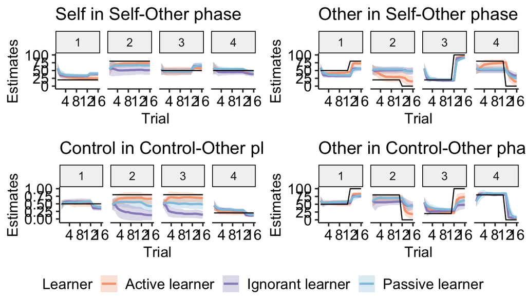

```r
cols_learners = c("Ignorant learner"="#998EC3","Passive learner"="#92C5DE","Active learner"="#F4A582")
dataB.all = rbind(dataB.mri%>%select(ID,game_number,phase,phase_trial,BL_self_mu,BL_ctrl_mu,BL_other_mu,IL_self_mu,IL_ctrl_mu,IL_other_mu,PL_self_mu,PL_ctrl_mu,PL_other_mu,self_mu,player_mu,control_level)%>%mutate(Sample='MRI',ID2=ID),
                  dataB.online%>%select(ID,game_number,phase,phase_trial,BL_self_mu,BL_ctrl_mu,BL_other_mu,IL_self_mu,IL_ctrl_mu,IL_other_mu,PL_self_mu,PL_ctrl_mu,PL_other_mu,self_mu,player_mu,control_level)%>%mutate(Sample='Online',ID2=ID+100)) %>%
  group_by(game_number,phase,phase_trial) %>%
  dplyr::summarize(self_mu=unique(self_mu), BL_selfmu = mean(BL_self_mu), IL_selfmu = mean(IL_self_mu), PL_selfmu = mean(PL_self_mu), BL_selfsd = sd(BL_self_mu), IL_selfsd = sd(IL_self_mu), PL_selfsd = sd(PL_self_mu),
                   player_mu=unique(player_mu), BL_othermu = mean(BL_other_mu), IL_othermu = mean(IL_other_mu), PL_othermu = mean(PL_other_mu), BL_othersd = sd(BL_other_mu), IL_othersd = sd(IL_other_mu), PL_othersd = sd(PL_other_mu),
                   control_level=unique(control_level), BL_ctrlmu = mean(BL_ctrl_mu), IL_ctrlmu = mean(IL_ctrl_mu), PL_ctrlmu = mean(PL_ctrl_mu), BL_ctrlsd = sd(BL_ctrl_mu), IL_ctrlsd = sd(IL_ctrl_mu), PL_ctrlsd = sd(PL_ctrl_mu)
  ) %>% distinct()
# plot with ratings in separate panels
ggarrange(common.legend=T,legend='bottom',
          dataB.all %>% filter(phase==1) %>% ggplot(., aes(x=phase_trial)) +
            geom_ribbon(aes(ymin=PL_selfmu-PL_selfsd,ymax=PL_selfmu+PL_selfsd, fill='Passive learner'),alpha=0.3) + geom_ribbon(aes(ymin=IL_selfmu-IL_selfsd,ymax=IL_selfmu+IL_selfsd, fill='Ignorant learner'),alpha=0.3) +
            geom_ribbon(aes(ymin=BL_selfmu-BL_selfsd,ymax=BL_selfmu+BL_selfsd, fill='Active learner'),alpha=0.3) +
            geom_line(aes(y=BL_selfmu,color='Active learner'),size=1) + geom_line(aes(y=IL_selfmu,color='Ignorant learner'),size=1) + geom_line(aes(y=PL_selfmu,color='Passive learner'),size=1) + geom_line(aes(y=self_mu),color='black') +
            ylim(-4,100) + scale_color_manual(values=cols_learners) + scale_fill_manual(values=cols_learners) +
            facet_grid(~game_number)+ ylab("Estimates") + xlab("Trial") + ggtitle('Self in Self-Other phase') + labs(colour='Learner',fill='Learner')+theme(legend.text = element_text(size=14)),
          dataB.all %>% filter(phase==1) %>% ggplot(., aes(x=phase_trial)) +
            geom_ribbon(aes(ymin=PL_othermu-PL_othersd,ymax=PL_othermu+PL_othersd, fill='Passive learner'),alpha=0.3) + geom_ribbon(aes(ymin=IL_othermu-IL_othersd,ymax=IL_othermu+IL_othersd, fill='Ignorant learner'),alpha=0.3) +
            geom_ribbon(aes(ymin=BL_othermu-BL_othersd,ymax=BL_othermu+BL_othersd, fill='Active learner'),alpha=0.3) +
            geom_line(aes(y=BL_othermu,color='Active learner'),size=1) + geom_line(aes(y=IL_othermu,color='Ignorant learner'),size=1) + geom_line(aes(y=PL_othermu,color='Passive learner'),size=1) + geom_line(aes(y=player_mu),color='black') +
            ylim(-4,100) + scale_color_manual(values=cols_learners) + scale_fill_manual(values=cols_learners) +
            facet_grid(~game_number)+ ylab("Estimates") + xlab("Trial") + ggtitle('Other in Self-Other phase') + labs(colour='Learner',fill='Learner'),
          dataB.all %>% filter(phase==3) %>% ggplot(., aes(x=phase_trial)) +
            geom_ribbon(aes(ymin=PL_ctrlmu-PL_ctrlsd,ymax=PL_ctrlmu+PL_ctrlsd, fill='Passive learner'),alpha=0.3) + geom_ribbon(aes(ymin=IL_ctrlmu-IL_ctrlsd,ymax=IL_ctrlmu+IL_ctrlsd, fill='Ignorant learner'),alpha=0.3) +
            geom_ribbon(aes(ymin=BL_ctrlmu-BL_ctrlsd,ymax=BL_ctrlmu+BL_ctrlsd, fill='Active learner'),alpha=0.3) +
            geom_line(aes(y=BL_ctrlmu,color='Active learner'),size=1) + geom_line(aes(y=IL_ctrlmu,color='Ignorant learner'),size=1) + geom_line(aes(y=PL_ctrlmu,color='Passive learner'),size=1) + geom_line(aes(y=control_level),color='black') +
            ylim(-0.07,1) + scale_color_manual(values=cols_learners) + scale_fill_manual(values=cols_learners) +
            facet_grid(~game_number)+ ylab("Estimates") + xlab("Trial") + ggtitle('Control in Control-Other phase') + labs(colour='Learner',fill='Learner'),
          dataB.all %>% filter(phase==3) %>% ggplot(., aes(x=phase_trial)) +
            geom_ribbon(aes(ymin=PL_othermu-PL_othersd,ymax=PL_othermu+PL_othersd, fill='Passive learner'),alpha=0.3) + geom_ribbon(aes(ymin=IL_othermu-IL_othersd,ymax=IL_othermu+IL_othersd, fill='Ignorant learner'),alpha=0.3) +
            geom_ribbon(aes(ymin=BL_othermu-BL_othersd,ymax=BL_othermu+BL_othersd, fill='Active learner'),alpha=0.3) +
            geom_line(aes(y=BL_othermu,color='Active learner'),size=1) + geom_line(aes(y=IL_othermu,color='Ignorant learner'),size=1) + geom_line(aes(y=PL_othermu,color='Passive learner'),size=1) + geom_line(aes(y=player_mu),color='black') +
            ylim(-4,100) + scale_color_manual(values=cols_learners) + scale_fill_manual(values=cols_learners) +
            facet_grid(~game_number)+ ylab("Estimates") + xlab("Trial") + ggtitle('Other in Control-Other phase') + labs(colour='Learner',fill='Learner')
)
```

```r
#ggsave(file.path(path$figs,'Supplementals','FigX_compmodels_avgratings_raw.jpg'),width = 34,height=18,units = 'cm')
```

## Supplementary figure 4c: AD performance in example participant

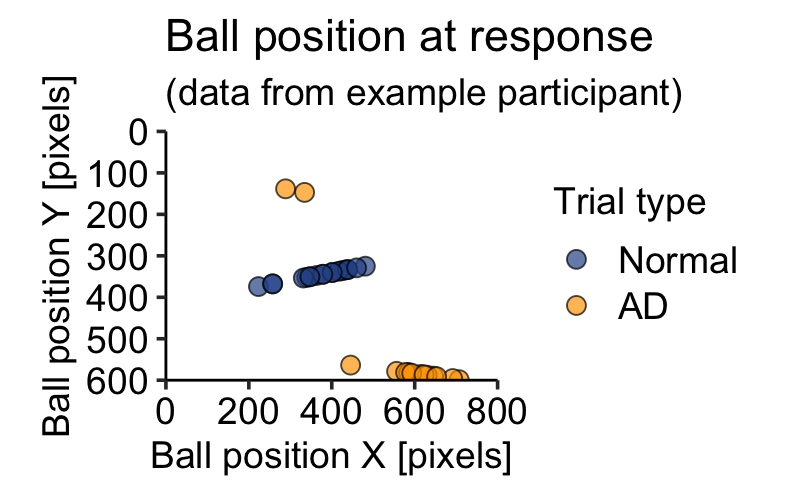

```r
dataB.mri %>% filter(ID==34,game_name=='rockslide') %>% ggplot(aes(x=PosXball,y=PosYball)) + geom_point(aes(fill=active_trial),color='black',shape=21,alpha=0.7,size=3) +
  scale_y_reverse(limits=c(600,0),expand=c(0,0)) + coord_fixed(ratio = 1) + scale_x_continuous(limits=c(0,800),expand=c(0,0)) +
  scale_fill_manual(values=c('#2F5597','orange'),name='Trial type',labels=c('Normal','AD')) +
  xlab('Ball position X [pixels]') + ylab('Ball position Y [pixels]') + ggtitle('Ball position at response',subtitle = '(data from example participant)') +
  theme_pubr(base_size=14) +
  theme(legend.position = 'right',legend.text = element_text(size=14),
        panel.background = element_rect(fill='transparent'), #transparent panel bg
        plot.background = element_rect(fill='transparent', color=NA), #transparent plot bg
        legend.background = element_rect(fill='transparent',color=NA), #transparent legend bg
        legend.box.background = element_rect(fill='transparent',color=NA) #transparent legend panel
  )
```

```r
#ggsave(file.path(path$figs,'Supplementals','FigX_task_AD_in_rockslide_s66.png'),width = 15,height=10,units = 'cm')
```

## Supplementary figure 8: Uncertainty dynamics

```r
lapply(c(list.files(file.path(path$save,'indivs_mri','all_subs'),pattern='_unc_AT12_drift.p',full.names = T),list.files(file.path(path$save,'indivs_online','all_subs'),pattern='_unc_AT12_drift.p',full.names = T)),load,.GlobalEnv)
```

```
[[1]]
[1] "fit_avg_unc_AT12_drift.p13.mri"

[[2]]
[1] "fit_avg_unc_AT12_drift.p13.online"
```

[figure not shown]

```r
transform4plot = function(data) {
  data = data %>% rename(AT1=active_1after1,AT2=active_2after1 ) %>% pivot_longer(cols=c(AT1,AT2,phase_trial,player_mu_drift1,phase),values_to=beta2plot,names_to = 'regressor')
  return(data)
}
unc2plot.avg13upd  = rbind(fit_avg_unc_AT12_drift.p13.mri[[df2plot]]      %>% transform4plot() %>% mutate(Sample='MRI'),     fit_avg_unc_AT12_drift.p13.online[[df2plot]]   %>% transform4plot() %>% mutate(Sample='Online'))
# uncertainty from start to finish, plotted like figure 2d
data2plot = rbind(dataB.mri %>% select(ID,game_number,phase,phase_trial,game_trial,BL_avg_unc,BL_self_unc,BL_other_unc,BL_ctrl_unc) %>% mutate(Sample='MRI'),
                  dataB.online %>% select(ID,game_number,phase,phase_trial,game_trial,BL_avg_unc,BL_self_unc,BL_other_unc,BL_ctrl_unc) %>% mutate(Sample='Online')) %>%
  filter(phase!=2,phase_trial%in%c(1,11)) %>%
  mutate(ID=as.factor(ID),Sample=factor(Sample,levels=c('MRI','Online')),phase_section=ifelse(phase_trial==1,1,2),BL_ctrl_unc=100*BL_ctrl_unc)  %>%
  select(-phase,-phase_trial,-game_trial,-game_number) %>%
  group_by(ID,Sample,phase_section) %>% dplyr::summarise(BL_avg_unc = mean(BL_avg_unc), BL_self_unc = mean(BL_self_unc,na.rm=T), BL_other_unc = mean(BL_other_unc), BL_ctrl_unc = mean(BL_ctrl_unc,na.rm=T)) %>% ungroup()
data2plot2 = data2plot %>% pivot_longer(.,cols=contains('unc'),names_to='unc',values_to = 'value') %>%
  mutate(unc_titles = ifelse(unc=='BL_ctrl_unc','Control uncertainty',ifelse(unc=='BL_self_unc','Self uncertainty',ifelse(unc=='BL_other_unc','Other uncertainty',ifelse(unc=='BL_avg_unc','Averaged uncertainty',NA)))))

# plot
lbls=c('AT1' = '1 trial\nafter AD', 'AT2' = '2 trials\nafter AD','phase_trial'='Trial','player_mu_drift1'='Other changed\nwithin phase','phase'='Task phase')
p1 = data2plot2 %>% ggerrorplot(.,'phase_section','value',desc_stat = 'mean_se',color='Sample',
                                ylab='Uncertainty', xlab='Time in phase',size=0.5,
                                add='jitter',add.params = list(alpha=0.5,size=0.1,shape=21,color='grey',fill='Sample')) +
  scale_x_discrete(labels=c("1" = "Start", "2" = "End"))+scale_color_manual(values=c('black','darkgrey')) + scale_fill_manual(values=c('black','darkgrey')) + scale_y_continuous(breaks=seq(0,120,25),limits = c(0,120)) +
  # for adding stars for significance, we actually need an anova - but this function can't do it so I modify the significance levels of the used ttest to reflect the correct stars that I manually computed in the following chunk
  geom_signif(comparisons = list(c("1", "2")), test.args = list(paired=T), map_signif_level=c("***"=0.001, "**"=0.01,"*"=0.05),y_position = 110,textsize = 7,vjust=0.5) +
  theme_pubr(base_size=14) +theme(legend.position = 'right',legend.text=element_text(size=14),axis.text.x = element_text(size=13),strip.text.x = element_text(size=14)) +
  facet_wrap(~unc_titles,nrow=1,ncol=4,strip.position = 'top',labeller = label_wrap_gen(width = 20))
p2 = rbind(
  dataB.mri %>% select(ID,game_number,phase,phase_trial,game_trial,BL_avg_unc,BL_self_unc,BL_other_unc,BL_ctrl_unc),
  dataB.online %>% select(ID,game_number,phase,phase_trial,game_trial,BL_avg_unc,BL_self_unc,BL_other_unc,BL_ctrl_unc)
) %>%
  group_by(game_number,phase,game_trial) %>%
  dplyr::summarise(BL_avg_unc = mean(BL_avg_unc), BL_self_unc = mean(BL_self_unc), BL_other_unc = mean(BL_other_unc), BL_ctrl_unc = 100*mean(BL_ctrl_unc),
                   BL_avg_sd  = sd(BL_avg_unc),   BL_self_sd  = sd(BL_self_unc),   BL_other_sd  = sd(BL_other_unc),   BL_ctrl_sd  = 100*sd(BL_ctrl_unc)) %>% distinct() %>%
  ggplot(aes(x=game_trial)) +
  geom_line(aes(y=BL_self_unc,color='Self'),size=1) + geom_line(aes(y=BL_other_unc,color='Other'),size=1) + geom_line(aes(y=BL_ctrl_unc,color='Control'),size=1) + geom_line(aes(y=BL_avg_unc,color='Averaged'),size=1) +
  facet_grid(~game_number)+ ylab("Uncertainty") + xlab("Trial") + labs(colour='Uncertainty') +
  geom_vline(xintercept=c(16.5,20.5), linetype='dashed') +
  scale_color_manual(values=c('Self'=cols$Self, 'Other' = cols$Other, 'Control'=cols$Control, 'Averaged' = 'black')) +
  theme_pubr(base_size=14) + theme(legend.text = element_text(size=14),legend.position='right',strip.text.x = element_text(size=14))
p3 = unc2plot.avg13upd %>%
  ggbarplot(.,'regressor','beta_estimate',add=c('mean_se','jitter'),fill='Sample',ylab='Effect on uncertainty',position = position_dodge(0.75),add.params=list(size='Sample',alpha=0.1,show.legend=F)) +
  geom_hline(yintercept = 0) + geom_text(aes(family='Courier'),x = 'AT1', y = -1.4,label='***',size=5) + geom_text(aes(family='Courier'),x = 'AT2', y = -1.4,label='***',size=5) +
  geom_text(aes(family='Courier'),x = 'phase_trial', y = -1.4,label='***',size=5) + geom_text(aes(family='Courier'),x = 'player_mu_drift1', y = 1.4,label='***',size=5) +
  scale_x_discrete(labels=lbls) + scale_fill_manual(values = c(cols$AD,cols$ADL)) + scale_size_manual(values=c(0.8,0.8)) +
  theme_pubr(base_size=14)+theme(legend.position = 'right', axis.title.x = element_blank(),legend.box.margin=margin(-10,-10,-10,-10), legend.text = element_text(size=14))
ggarrange(p1,p2,'',p3,nrow=4,heights=c(1,1,0.2,0.8))
```

```r
#ggsave(file.path(path$figs,'Supplementals','FigX_compmodels_uncertainty_raw_revision-1.jpg'),width = 28,height=25,units = 'cm')
```

Same significance tests as for figure 2d

```r
# A) Averaged uncertainty
# anova across samples: between = sample; within: time in block
data4anova = data2plot %>% pivot_longer(cols = contains('unc'),values_to = 'uncertainty',names_to='utype') %>% as.data.frame() %>% mutate(ID = ifelse(Sample=='Online',as.numeric(ID)+200,ID),phase_section=as.factor(phase_section)) # make ID a unique number across samples
print('AVG UNCERTAINTY'); rstatix::anova_test(data = data4anova%>%filter(utype=='BL_avg_unc'), dv = uncertainty, wid = ID, within=phase_section,between = Sample)
```

```
[1] "AVG UNCERTAINTY"
ANOVA Table (type III tests)

                Effect DFn DFd        F        p p<.05   ges
1               Sample   1  65    6.719 1.20e-02     * 0.049
2        phase_section   1  65 7103.739 4.11e-68     * 0.982
3 Sample:phase_section   1  65    6.719 1.20e-02     * 0.049
```

```r
# Self
# anova across samples: between = sample; within: time in block -> post-hoc ttests within sample not done bc no sign main effect or interaction with sample
print("SELF UNCERTAINTY");rstatix::anova_test(data = data4anova%>%filter(utype=='BL_self_unc'), dv = uncertainty, wid = ID, within = phase_section, between = c(Sample))
```

```
[1] "SELF UNCERTAINTY"
ANOVA Table (type III tests)

                Effect DFn DFd         F        p p<.05   ges
1               Sample   1  65     1.545 2.18e-01       0.012
2        phase_section   1  65 10184.586 3.69e-73     * 0.987
3 Sample:phase_section   1  65     1.545 2.18e-01       0.012
```

```r
# OTHER
# anova across samples: between = sample; within: time in block
print("OTHER UNCERTAINTY");rstatix::anova_test(data = data4anova%>%filter(utype=='BL_other_unc'), dv = uncertainty, wid = ID, within = phase_section, between = c(Sample))
```

```
[1] "OTHER UNCERTAINTY"
ANOVA Table (type III tests)

                Effect DFn DFd        F        p p<.05   ges
1               Sample   1  65   10.856 2.00e-03     * 0.077
2        phase_section   1  65 6249.368 2.54e-66     * 0.980
3 Sample:phase_section   1  65   10.856 2.00e-03     * 0.077
```

```r
# Ctrl RAING
# anova across samples: between = sample; within: time in block
print("CTRL UNCERTAINTY");rstatix::anova_test(data = data4anova%>%filter(utype=='BL_ctrl_unc'), dv = uncertainty, wid = ID, within = phase_section, between = c(Sample))
```

```
[1] "CTRL UNCERTAINTY"
ANOVA Table (type III tests)

                Effect DFn DFd        F        p p<.05   ges
1               Sample   1  65    2.606 1.11e-01       0.039
2        phase_section   1  65 3807.873 2.02e-59     * 0.983
3 Sample:phase_section   1  65    2.606 1.11e-01       0.039
```

[1] “AVG UNCERTAINTY” ANOVA Table (type III tests)

Effect DFn DFd F p p<.05 ges 1 Sample 1 65 6.719 1.20e-02 * 0.049 2 phase_section 1 65 7103.739 4.11e-68 * 0.982 3 Sample:phase_section 1 65 6.719 1.20e-02 * 0.049 [1] “SELF UNCERTAINTY” ANOVA Table (type III tests)

Effect DFn DFd F p p<.05 ges 1 Sample 1 65 1.545 2.18e-01 0.012 2 phase_section 1 65 10184.586 3.69e-73 * 0.987 3 Sample:phase_section 1 65 1.545 2.18e-01 0.012 [1] “OTHER UNCERTAINTY” ANOVA Table (type III tests)

Effect DFn DFd F p p<.05 ges 1 Sample 1 65 10.856 2.00e-03 * 0.077 2 phase_section 1 65 6249.368 2.54e-66 * 0.980 3 Sample:phase_section 1 65 10.856 2.00e-03 * 0.077 [1] “CTRL UNCERTAINTY” ANOVA Table (type III tests)

Effect DFn DFd F p p<.05 ges 1 Sample 1 65 2.606 1.11e-01 0.039 2 phase_section 1 65 3807.873 2.02e-59 * 0.983 3 Sample:phase_section 1 65 2.606 1.11e-01 0.039

## Supplementary figure 7: Correlations between true levels and uncertainties

[figure not shown]

```r
rbind(
  dataB.mri %>% filter(phase!=2) %>% select(BL_self_unc,BL_other_unc,BL_ctrl_unc,BL_avg_unc,self_mu,player_mu,control_level,feedback),
  dataB.online %>% filter(phase!=2) %>% select(BL_self_unc,BL_other_unc,BL_ctrl_unc,BL_avg_unc,self_mu,player_mu,control_level,feedback))%>%
  rename(`Control uncertainty` = BL_ctrl_unc, `Other uncertainty` = BL_other_unc, `Self uncertainty` = BL_self_unc, `Uncertainty` = BL_avg_unc,
         `True control level` = control_level, `True self performance level` = self_mu, `True other performance level` = player_mu, `Feedback` = feedback) %>%
  cor(use = 'pairwise.complete.obs') %>% round(2) %>% ggcorrplot::ggcorrplot(lab=T,show.legend=F)
```

```r
#ggsave(file.path(path$figs,'Supplementals','FigX_task_correlations_raw_revision-1.jpg'),width = 15,height=15,units = 'cm')
```

## Supplementary figure 11: rating accuracies and AD over task blocks

[figure not shown]

```r
# prep accuracy data
compute_accuracies = function(data) {
  data %>% mutate(rate_self_err_max  = ifelse(self_mu<50,100 - self_mu, self_mu),
                  rate_self_acc      = ifelse(phase==1,100 * (1 - rate_self_err / rate_self_err_max),NA),
                  rate_other_err_max = ifelse(player_mu<50,100 - player_mu, player_mu),
                  rate_other_acc     = 100 * (1 - rate_other_err / rate_other_err_max),
                  rate_ctrl_err_max  = ifelse(control_level<0.5,1 - control_level, control_level),
                  rate_ctrl_acc      = 100 * (1 - rate_ctrl_err / rate_ctrl_err_max))
}
dataB.mri = compute_accuracies(dataB.mri); dataB.online = compute_accuracies(dataB.online)
dataB.all4plot.acc = rbind(dataB.mri %>% select(ID,game_number,phase,phase_trial,rate_self_acc,rate_other_acc,rate_ctrl_acc) %>% mutate(Sample='MRI'),
                           dataB.online %>% select(ID,game_number,phase,phase_trial,rate_self_acc,rate_other_acc,rate_ctrl_acc) %>% mutate(Sample='Online')) %>%
  filter(phase_trial==16) %>%
  group_by(ID,game_number,Sample) %>% mutate(rate_other_acc_mu = mean(rate_other_acc,na.rm=T)) %>%
  pivot_longer(cols=c(rate_self_acc,rate_other_acc,rate_ctrl_acc,rate_other_acc_mu),names_to='Accuracy',values_to='rating_accuracy') %>%
  filter((phase==1 & Accuracy=='rate_self_acc') | (phase==3 & Accuracy=='rate_ctrl_acc') | (phase==1 & Accuracy=='rate_other_acc_mu')) %>%
  mutate(Accuracy = ifelse(Accuracy=='rate_self_acc','Self',ifelse(Accuracy=='rate_other_acc_mu','Other','Control')),
         ID = ifelse(Sample=='Online',as.numeric(ID)+100,ID))%>%as.data.frame()
# prep AD plot
compute_prop_AD = function(data) {
  data %>% group_by(ID,game_number) %>% dplyr::summarise(n_AD = sum(as.numeric(active_trial)-1) ,prop_AD = 100 * n_AD / 36) # 36 trials per game
}
dataB.all4plot.AD = rbind(compute_prop_AD(dataB.mri)%>%mutate(Sample='MRI'), compute_prop_AD(dataB.online)%>%mutate(Sample='Online')) %>% mutate(ID = ifelse(Sample=='Online',as.numeric(ID)+100,ID)) %>% as.data.frame()
# plot
p1 = dataB.all4plot.acc %>%
  ggplot(aes(x=game_number)) +
  geom_point(aes(y=rating_accuracy,color=Accuracy),size=0.5,alpha=0.2,position = position_dodge(0.75)) +
  ylab('Rating accuracy [%]') + xlab('Task block') + labs(fill='Rating type') +
  stat_summary(aes(y=rating_accuracy,color=Accuracy),geom='pointrange',position = position_dodge(0.75),fun.data=mean_se) +
  stat_summary(aes(y=rating_accuracy,color=Accuracy),geom='line',position = position_dodge(0.75),fun=mean) +
  scale_color_manual(values=c('Self'=cols$Self, 'Other' = cols$Other, 'Control'=cols$Control)) + theme_pubr(base_size=14) + theme(legend.position='bottom')
p2 = dataB.all4plot.AD %>%
  ggplot(aes(x=game_number)) +
  geom_point(aes(y=prop_AD),size=0.5,alpha=0.2,position = position_dodge(0.75),color=cols$AD) +
  ylab('Proportion of AD trials [%]') + xlab('Task block') + labs(fill='Rating type') +
  stat_summary(aes(y=prop_AD),fun.data = mean_se, geom = "pointrange",color=cols$AD) +
  stat_summary(aes(y=prop_AD),geom='line',position = position_dodge(0.75),fun=mean,color=cols$AD) + theme_pubr(base_size=14)
ggarrange(p1,p2,ncol=2,widths=c(2,1),align='h',labels='AUTO',font.label = list(size=22))
```

```r
#ggsave(file.path(path$figs,'Supplementals','FigX_beh_acc_AD_over_blocks_revision-1.jpg'),width = 28,height=12,units = 'cm')

# anova
print('Self rating accuracy'); rstatix::anova_test(data = dataB.all4plot.acc%>%filter(Accuracy=='Self'), dv = rating_accuracy, wid = ID, within = game_number, between = c(Sample))
```

```
[1] "Self rating accuracy"
ANOVA Table (type III tests)

$ANOVA
              Effect DFn DFd      F        p p<.05   ges
1             Sample   1  65  0.530 4.69e-01       0.002
2        game_number   3 195 59.499 2.35e-27     * 0.401
3 Sample:game_number   3 195  0.887 4.49e-01       0.010

$`Mauchly's Test for Sphericity`
              Effect     W     p p<.05
1        game_number 0.816 0.024     *
2 Sample:game_number 0.816 0.024     *

$`Sphericity Corrections`
              Effect   GGe       DF[GG]    p[GG] p[GG]<.05   HFe       DF[HF]    p[HF] p[HF]<.05
1        game_number 0.872 2.62, 170.04 3.54e-24         * 0.912 2.74, 177.81 3.63e-25         *
2 Sample:game_number 0.872 2.62, 170.04 4.37e-01           0.912 2.74, 177.81 4.41e-01
```

```r
print('Other rating accuracy'); rstatix::anova_test(data = dataB.all4plot.acc%>%filter(Accuracy=='Other'), dv = rating_accuracy, wid = ID, within = game_number, between = c(Sample))
```

```
[1] "Other rating accuracy"
ANOVA Table (type III tests)

$ANOVA
              Effect DFn DFd      F        p p<.05   ges
1             Sample   1  65  2.026 1.59e-01       0.006
2        game_number   3 195 35.983 1.49e-18     * 0.308
3 Sample:game_number   3 195  4.738 3.00e-03     * 0.055

$`Mauchly's Test for Sphericity`
              Effect     W        p p<.05
1        game_number 0.635 2.38e-05     *
2 Sample:game_number 0.635 2.38e-05     *

$`Sphericity Corrections`
              Effect   GGe       DF[GG]    p[GG] p[GG]<.05   HFe       DF[HF]    p[HF] p[HF]<.05
1        game_number 0.789 2.37, 153.83 3.84e-15         * 0.821 2.46, 160.02 1.18e-15         *
2 Sample:game_number 0.789 2.37, 153.83 7.00e-03         * 0.821 2.46, 160.02 6.00e-03         *
```

```r
print('Control rating accuracy'); rstatix::anova_test(data = dataB.all4plot.acc%>%filter(Accuracy=='Control'), dv = rating_accuracy, wid = ID, within = game_number, between = c(Sample))
```

```
[1] "Control rating accuracy"
ANOVA Table (type III tests)

$ANOVA
              Effect DFn DFd      F        p p<.05   ges
1             Sample   1  65  2.161 1.46e-01       0.007
2        game_number   3 195 11.357 6.74e-07     * 0.119
3 Sample:game_number   3 195  0.738 5.31e-01       0.009

$`Mauchly's Test for Sphericity`
              Effect     W        p p<.05
1        game_number 0.685 0.000211     *
2 Sample:game_number 0.685 0.000211     *

$`Sphericity Corrections`
              Effect   GGe      DF[GG]    p[GG] p[GG]<.05   HFe       DF[HF]    p[HF] p[HF]<.05
1        game_number 0.799 2.4, 155.77 6.42e-06         * 0.832 2.49, 162.14 4.45e-06         *
2 Sample:game_number 0.799 2.4, 155.77 5.03e-01           0.832 2.49, 162.14 5.08e-01
```

```r
print('AD proportion'); rstatix::anova_test(data = dataB.all4plot.AD, dv = prop_AD, wid = ID, within = game_number, between = c(Sample))
```

```
[1] "AD proportion"
ANOVA Table (type III tests)

$ANOVA
              Effect DFn DFd     F     p p<.05     ges
1             Sample   1  65 5.457 0.023     * 0.05600
2        game_number   3 195 0.149 0.930       0.00067
3 Sample:game_number   3 195 2.052 0.108       0.00900

$`Mauchly's Test for Sphericity`
              Effect     W     p p<.05
1        game_number 0.818 0.025     *
2 Sample:game_number 0.818 0.025     *

$`Sphericity Corrections`
              Effect   GGe       DF[GG] p[GG] p[GG]<.05   HFe      DF[HF] p[HF] p[HF]<.05
1        game_number 0.884 2.65, 172.29 0.912           0.925 2.77, 180.3 0.919
2 Sample:game_number 0.884 2.65, 172.29 0.116           0.925 2.77, 180.3 0.113
```

```r
# post-hoc t-tests comparing accuracies of first and last game block
print("Self rating accuracy"); t.test(dataB.all4plot.acc %>% filter(Accuracy=='Self',game_number==4)%>%pull(rating_accuracy),dataB.all4plot.acc %>% filter(Accuracy=='Self',game_number==1)%>%pull(rating_accuracy),paired = T)
```

```
[1] "Self rating accuracy"

    Paired t-test

data:  dataB.all4plot.acc %>% filter(Accuracy == "Self", game_number == 4) %>% pull(rating_accuracy) and dataB.all4plot.acc %>% filter(Accuracy == "Self", game_number == 1) %>% pull(rating_accuracy)
t = 10.381, df = 66, p-value = 1.646e-15
alternative hypothesis: true mean difference is not equal to 0
95 percent confidence interval:
 23.28643 34.37663
sample estimates:
mean difference
       28.83153
```

```r
print("Other rating accuracy"); t.test(dataB.all4plot.acc %>% filter(Accuracy=='Other',game_number==4)%>%pull(rating_accuracy),dataB.all4plot.acc %>% filter(Accuracy=='Other',game_number==1)%>%pull(rating_accuracy),paired = T)
```

```
[1] "Other rating accuracy"

    Paired t-test

data:  dataB.all4plot.acc %>% filter(Accuracy == "Other", game_number == 4) %>% pull(rating_accuracy) and dataB.all4plot.acc %>% filter(Accuracy == "Other", game_number == 1) %>% pull(rating_accuracy)
t = -5.5701, df = 66, p-value = 5.047e-07
alternative hypothesis: true mean difference is not equal to 0
95 percent confidence interval:
 -26.61738 -12.57071
sample estimates:
mean difference
      -19.59405
```

```r
print("Control rating accuracy"); t.test(dataB.all4plot.acc %>% filter(Accuracy=='Control',game_number==4)%>%pull(rating_accuracy),dataB.all4plot.acc %>% filter(Accuracy=='Control',game_number==1)%>%pull(rating_accuracy),paired = T)
```

```
[1] "Control rating accuracy"

    Paired t-test

data:  dataB.all4plot.acc %>% filter(Accuracy == "Control", game_number == 4) %>% pull(rating_accuracy) and dataB.all4plot.acc %>% filter(Accuracy == "Control", game_number == 1) %>% pull(rating_accuracy)
t = 4.2742, df = 66, p-value = 6.307e-05
alternative hypothesis: true mean difference is not equal to 0
95 percent confidence interval:
 11.18844 30.80410
sample estimates:
mean difference
       20.99627
```

[1] “Self rating accuracy” ANOVA Table (type III tests)

$ANOVA Effect DFn DFd F p p<.05 ges 1 Sample 1 65 0.530 4.69e-01 0.002 2 game_number 3 195 59.499 2.35e-27 * 0.401 3 Sample:game_number 3 195 0.887 4.49e-01 0.010

$`Mauchly's Test for Sphericity` Effect W p p<.05 1 game_number 0.816 0.024 *2 Sample:game_number 0.816 0.024*

$`Sphericity Corrections` Effect GGe DF[GG] p[GG] p[GG]<.05 HFe DF[HF] p[HF] p[HF]<.05 1 game_number 0.872 2.62, 170.04 3.54e-24 * 0.912 2.74, 177.81 3.63e-25 * 2 Sample:game_number 0.872 2.62, 170.04 4.37e-01 0.912 2.74, 177.81 4.41e-01

[1] “Other rating accuracy” ANOVA Table (type III tests)

$ANOVA Effect DFn DFd F p p<.05 ges 1 Sample 1 65 2.026 1.59e-01 0.006 2 game_number 3 195 35.983 1.49e-18 * 0.308 3 Sample:game_number 3 195 4.738 3.00e-03 * 0.055

$`Mauchly's Test for Sphericity` Effect W p p<.05 1 game_number 0.635 2.38e-05 *2 Sample:game_number 0.635 2.38e-05*

$`Sphericity Corrections` Effect GGe DF[GG] p[GG] p[GG]<.05 HFe DF[HF] p[HF] p[HF]<.05 1 game_number 0.789 2.37, 153.83 3.84e-15 * 0.821 2.46, 160.02 1.18e-15 *2 Sample:game_number 0.789 2.37, 153.83 7.00e-03* 0.821 2.46, 160.02 6.00e-03 *

[1] “Control rating accuracy” ANOVA Table (type III tests)

$ANOVA Effect DFn DFd F p p<.05 ges 1 Sample 1 65 2.161 1.46e-01 0.007 2 game_number 3 195 11.357 6.74e-07 * 0.119 3 Sample:game_number 3 195 0.738 5.31e-01 0.009

$`Mauchly's Test for Sphericity` Effect W p p<.05 1 game_number 0.685 0.000211 *2 Sample:game_number 0.685 0.000211*

$`Sphericity Corrections` Effect GGe DF[GG] p[GG] p[GG]<.05 HFe DF[HF] p[HF] p[HF]<.05 1 game_number 0.799 2.4, 155.77 6.42e-06 * 0.832 2.49, 162.14 4.45e-06 * 2 Sample:game_number 0.799 2.4, 155.77 5.03e-01 0.832 2.49, 162.14 5.08e-01

[1] “AD proportion” ANOVA Table (type III tests)

$ANOVA Effect DFn DFd F p p<.05 ges 1 Sample 1 65 5.457 0.023 * 0.05600 2 game_number 3 195 0.149 0.930 0.00067 3 Sample:game_number 3 195 2.052 0.108 0.00900

$`Mauchly's Test for Sphericity` Effect W p p<.05 1 game_number 0.818 0.025 *2 Sample:game_number 0.818 0.025*

$`Sphericity Corrections` Effect GGe DF[GG] p[GG] p[GG]<.05 HFe DF[HF] p[HF] p[HF]<.05 1 game_number 0.884 2.65, 172.29 0.912 0.925 2.77, 180.3 0.919  
2 Sample:game_number 0.884 2.65, 172.29 0.116 0.925 2.77, 180.3 0.113

[1] “Self rating accuracy”

Paired t-test

data: dataB.all4plot.acc %>% filter(Accuracy == “Self”, game_number == 4) %>% pull(rating_accuracy) and dataB.all4plot.acc %>% filter(Accuracy == “Self”, game_number == 1) %>% pull(rating_accuracy) t = 10.381, df = 66, p-value = 1.646e-15 alternative hypothesis: true mean difference is not equal to 0 95 percent confidence interval: 23.28643 34.37663 sample estimates: mean difference 28.83153

[1] “Other rating accuracy”

Paired t-test

data: dataB.all4plot.acc %>% filter(Accuracy == “Other”, game_number == 4) %>% pull(rating_accuracy) and dataB.all4plot.acc %>% filter(Accuracy == “Other”, game_number == 1) %>% pull(rating_accuracy) t = -5.5701, df = 66, p-value = 5.047e-07 alternative hypothesis: true mean difference is not equal to 0 95 percent confidence interval: -26.61738 -12.57071 sample estimates: mean difference -19.59405

[1] “Control rating accuracy”

Paired t-test

data: dataB.all4plot.acc %>% filter(Accuracy == “Control”, game_number == 4) %>% pull(rating_accuracy) and dataB.all4plot.acc %>% filter(Accuracy == “Control”, game_number == 1) %>% pull(rating_accuracy) t = 4.2742, df = 66, p-value = 6.307e-05 alternative hypothesis: true mean difference is not equal to 0 95 percent confidence interval: 11.18844 30.80410 sample estimates: mean difference 20.99627